# 开篇词｜为什么你要系统学习计算机的内存知识？

[figure not shown]

# 开篇词｜为什么你要系统学习计算机的内存知识？

2021-10-25 海纳

《编程高手必学的内存知识》

课程介绍

[figure not shown]

### 讲述：海纳

[interactive chart not shown]

你好，我是海纳，欢迎来到《编程高手必学的内存知识》的课堂。

我曾经是 Huawei JDK 团队的负责人，现在是华为鲲鹏生态的布道师，同时还在负责华为编译器领域的相关创新工作。2019 年我出版了《自己动手写 Python 虚拟机》一书。这两年，我利用业余时间又筹备了一本《从零开始写 Linux 内核》，预计明年上市。

计算机内存可以说是我的老朋友了。我和它结缘于我对基础软件开发的热爱。2007 年，我本科毕业，在人大金仓从事国产数据库开发。

记得有一次，我在公司看 B+ 树代码。我之前一直都搞不懂 B+ 树为什么要这么设计，直到那段时间，我研究 Linux 内核代码，看到磁盘 IO 和页缓存算法时才恍然大悟。我发现，原来我对很多技术的不理解，是来自于我计算机内存管理这些知识的匮乏。

后来，我又去读了研。2012 年，研究生毕业后，我去了网易做游戏开发，偏离了我曾经热爱的基础软件开发领域，但我居然又遇见了我的“老朋友”，内存管理。网易大量的游戏逻辑都是使用 Python 虚拟机构建的，但是由于 Python 采用了引用计数法进行自动内存管理，使用不当的时候，很容易发生大量的模型文件因循环引用不能自动释放的问题。

为了解决这个问题，我就希望能在 Python 虚拟机中引入基于复制的内存管理算法。所以，我就打开 Python 虚拟机的源代码，研究它的内存管理部分，做了一些尝试，虽然最终未能商业落地，但却收获了宝贵的经验。这些经验都总结在《自己动手写 Python 虚拟机》这本书里了。

两年后，我加入了华为，从事 Huawei JDK 的研发工作。再一次回到基础软件开发领域的我，又跟内存管理“杠”上了。那时，我遇到过一个非常棘手的问题。

这个问题的表象是，在鲲鹏 CPU 上，SynchronousQueue（SQ）会卡死线程。因为 SQ 这个结构使用了多个 volatile 变量，volatile 的读写规则是在 Java 内存模型（Java Memory Model, JMM）中定义的，而华为鲲鹏芯片采用的是弱内存模型。所以，我们要解决这个问题，就不光要对 JMM 非常熟悉，还要对 CPU 的缓存管理有深入的理解。再加上，SQ 的具体实现会经过 HotSpot C2 编译器的优化，因此，我们同时还要搞清楚编译器是如何对内存操作进行翻译和优化的。

为了解决这个问题，我查阅了 JSR133 文档、CPU 的设计手册、JVM 的编译器设计和内存管理设计，还有多核 CPU 的操作系统设计等资料，深刻感受到想要分析这种涉及多个领域的问题，必须全面掌握内存相关的软硬件知识。

如果说，我与计算机内存的缘分，来自于我对基础软件开发和计算机底层原理的偏爱。那么今天，我想从更理性的、自身发展规划的角度看，和你谈谈为什么要系统地学习内存知识？

## 为什么我建议你系统学习内存知识？

现在，聊到程序员这个行业，逃不开的话题就是”职业生涯的 35 岁危机”。而且，你也能感受到，每年都有大量的人转行到计算机，初级的、写 CRUD 逻辑的人数已经逐渐见顶，出现供大于求的情况。

但是另一方面，结构性缺人又是非常常见的现象，很多公司还是感觉很难招到合适的开发人员。就拿我们编译器领域来说，招聘合适的人才，周期往往都要拉长到一年。

这是因为，在互联网的早期发展阶段，国内的 ICT 公司更多还是直接使用欧美的基础设施和技术，例如大型服务器、操作系统、数据库、编程语言、编译器、网络协议等等。随着国内企业的规模越来越大，各种定制化的需求也层出不穷，很多企业越来越希望自己能维护和修改基础设施。所以，当前市场对能进行底层开发的系统级程序员的需求也就越来越大。这对我们个人来说，是一个突破职业瓶颈的好机会。

那么，如何从一个应用开发程序员成长为资深的系统级程序员呢？

绕不开的一点是，我们需要熟练掌握 CPU 的工作原理、操作系统原理、编译器原理、分布式软件、图形渲染和数据库原理。如果从这些庞大的知识体系中选择一条脉络的话，我还是会推荐以内存管理为线索去进行学习。

举个例子，在 C 语言编写的程序中，一个变量要经过编译器、链接器、加载器和操作系统的进程管理，然后再经过 CPU 的 MMU 模块，才能最终出现在真正的物理内存里。如果你能把这个过程讲清楚了，那就说明你对编译、链接、加载、操作系统和 CPU 的工作原理有了相当的理解。所以说，内存管理的知识就相当于纲领，纲举则目张。

## 为什么内存相关知识这么难学？

从我个人的学习经历中也可以看出来，想学好内存管理，必须要掌握 CPU 核设计知识、CPU 的段页式管理等知识，还要深入了解操作系统的内存管理模块、编译器的内存分配、并发锁、基础库的设计原理等等。整体的知识结构，你可以参考下面这张图：

[figure not shown]

这里面涉及的知识覆盖了《数字电路设计》、《计算机原理》、《微处理器架构》、《体系结构》、《操作系统》、《编译原理》，还有各种编译语言库和虚拟机等等。每一点拎出来，都是一门独立的课程。即使你是在国内最好的计算机院校，想在这些课程里都取得高分也是非常困难的。更不要说，这些课程还没有涉及最新、最前沿的体系结构。

所以，我们不难看出，内存相关的知识体系的特点是：

内容非常多，涉及的学科特别多。软硬件的工作原理都得掌握才能学得好。

内容非常散，不成体系。高校里传统的课程都是分层水平设置的。想学好内存管理的知识，需要将它从不同的课程拉取出来，自己进行合并总结才能最终形成知识体系。

针对这些难点，我设计了这套课程，希望能避免水平式讲解方式难以形成体系的缺点，通过垂直化地学习软硬件相关知识，能让你快速地形成知识体系。

## 这门课是怎么设计的？

我们的课程分为三个部分：软件篇，硬件篇和自动内存管理篇。

### 软件篇

这一部分，我们会以操作系统为核心，将进程和内存的关系彻底讲清楚，让你对操作系统、编译器，以及应用程序的运行原理有深入的理解。这样，当你遇到进程 crash 时，分析 coredump、查看内存映射等都能游刃有余。

具体来讲，操作系统是软硬件设计的核心，它管理着所有的硬件资源，同时又为各种运行在它上面的应用程序提供服务。而内存是计算机的核心资源之一，如何高效地管理内存是操作系统的基础任务，甚至可以说是最重要的任务，它深刻影响着应用程序使用内存的方式。

而且，编译器和应用程序都是围绕这个核心来构建的。所以，在具体的讲述上，我们会采取由核心向外延的方式，把软件篇的知识都给你串联起来，如下图所示。

[figure not shown]

另外，我们这个专栏所举的例子都是运行在 Linux 系统上的，采用的编译器是 gcc，Java 语言使用的 JVM 是 Huawei JDK。我希望你在学习时候也准备好相关的运行环境，只要 Linux 内核不低于 4.1，gcc 版本不低于 4.8，JDK 版本不低于 8 就可以了。

### 硬件篇

这一部分，我们将会学习与内存相关的计算机体系架构，包括存储器电路、存储体系结构和多核 CPU 内存模型。

通过这部分的学习，你可以快速掌握缓存原理、多核 CPU 通信的核心知识，让你最大限度地使用好缓存，写出正确而高效的代码。同时，我们课程里对硬件知识的讲解，还可以让你掌握 CPU 设计一些简单原理，并且在此基础上，可以深入地学习 RISC-V 等开源 CPU 的实现。

我们都知道，随着 CPU 主频的提升越来越困难，厂商的主流做法是使用更多的 CPU 和更多的核对计算进行并行加速。这个时候，如何保证 CPU 核间的数据同步就成了硬件工程师的一大挑战，系统程序员必须得对这些原理有足够了解，才能写出正确高效的代码。

在讲存储器电路的时候，你会发现，根据不同的物理特性原理，人们制作了不同的存储器件，有的成本高、容量小，但速度快；有的则是成本低、容量大，但速度慢。而如何合理使用不同的器件构建一套高效的系统，让各种存储器件“扬长避短”，就是我们在计算机体系结构方面要重点研究的内容。

从下面这张图你也可以看到，硬件的结构是从下到上层层搭建的。所以，我会采用自底向上的讲解方式，带你理解存储系统是怎样由简单的器件一步步变得越来越复杂的。

[figure not shown]

### 内存管理篇

在这一部分，我们的关注点会从计算机软硬件，转向对具体内存管理算法的学习。

我们知道，Java、Go、Python、JavaScript 等语言的内存都是自动管理的，也就是由语言虚拟机托管的，所以，开发者不需要关心内存的申请和释放的问题，我们把这种类型的语言称为 Managed Language。

自动内存管理极大地减少了程序员的心智负担。但是，作为程序员，如果你不了解自动内存管理的原理，还是会遇到各种各样的问题，比如，垃圾回收时 stop the world 带来的服务器失去响应、out of memory error 等等。这也是为什么，JVM 的内存管理一直都是 Java 程序员的热门话题。在这个课程里，我们将在内存管理篇把这部分内容一次性讲透。

总的来说，内存管理算法一直在不断克服以前算法的缺点，持续向前演进，而我们这部分整体的讲述逻辑，就是按照算法的演进逻辑进行的。

以上就是软件篇，硬件篇和自动内存管理篇的主要内容，整个课程的详细目录，我也放在了这里，你可以看一下：

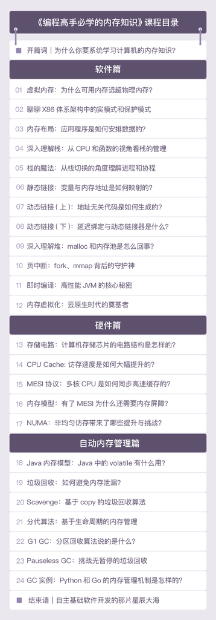

在最后，我想说成长为系统程序员，不仅仅能帮你突破职业瓶颈，提升个人的薪酬待遇，更重要的是，这是顺应国情和行业发展大趋势的选择。在当前复杂的国际环境下，我们要走出一条自主可控的芯片设计和基础软件设计之路，这是迫在眉睫的事情。我希望，未来能有越来越多的开发者从事 CPU 设计，操作系统和编译器开发。如果你也是这么想的，那么这个专栏可能就是你最好的启蒙，一起开始吧。

[figure not shown]

## 精选留言(6)

[figure not shown]

- jjn0703

[figure not shown]

  2021-10-25

  听过老师几次直播，干货满满，感谢。话说，准备要用的Huawei JDK与我们平常用的JDK有什么区别么？

  作者回复: 有一些arm分支上的特有问题，openjdk的修复合入了高版本，低版本openjdk不管了。Huawei jdk低版本也会修复。

[figure not shown]

- Noah

  2021-10-25

  今年疯狂学习操作系统知识，不为别的， 就为更好的自己！

[figure not shown]

- 飞

  2021-10-25

  直播有回放吗

  编辑回复: 有的，第二天会更新到专栏的“课程导学”章节里～ 另外，B站上关注极客时间官方账号，也可查看直播回放哦～

[figure not shown]

- 。。。

[figure not shown]

  2021-10-26

  是一直要努力的方向，但是任重道远

  **

[figure not shown]

- kylin

  2021-10-25

  看了老师之前的直播，非常精彩，果断买了

  **

- Geek_24df3c

  2021-10-25

  华为jdk是开源的吗

  **